# 2. Setup Check

Use this notebook to confirm that R, `ggplot2`, and Quarto rendering work on your computer.

After opening this file:

- In RStudio, click `Render` in the area on top of the file text.
- In Positron, click `Preview` in the area on top of the file text.

If rendering works, the checks below should run automatically and produce an HTML file with a table and plot.

# Check 1: R Works

This calculation should run during rendering.

```r
2 + 2
```

```
[1] 4
```

You should see `4` in the output.

# Check 2: Data Works

R includes a small built-in dataset called `mtcars`. We can use it to test data work without downloading anything else.

```r
mtcars |>
  head()
```

```
                   mpg cyl disp  hp drat    wt  qsec vs am gear carb
Mazda RX4         21.0   6  160 110 3.90 2.620 16.46  0  1    4    4
Mazda RX4 Wag     21.0   6  160 110 3.90 2.875 17.02  0  1    4    4
Datsun 710        22.8   4  108  93 3.85 2.320 18.61  1  1    4    1
Hornet 4 Drive    21.4   6  258 110 3.08 3.215 19.44  1  0    3    1
Hornet Sportabout 18.7   8  360 175 3.15 3.440 17.02  0  0    3    2
Valiant           18.1   6  225 105 2.76 3.460 20.22  1  0    3    1
```

# Check 3: Summaries Work

This summary should run during rendering.

```r
mtcars |>
  summarise(
    rows = n(),
    average_mpg = mean(mpg),
    minimum_mpg = min(mpg),
    maximum_mpg = max(mpg)
  )
```

```
  rows average_mpg minimum_mpg maximum_mpg
1   32    20.09062        10.4        33.9
```

# Check 4: ggplot2 Works

This plot should run during rendering.

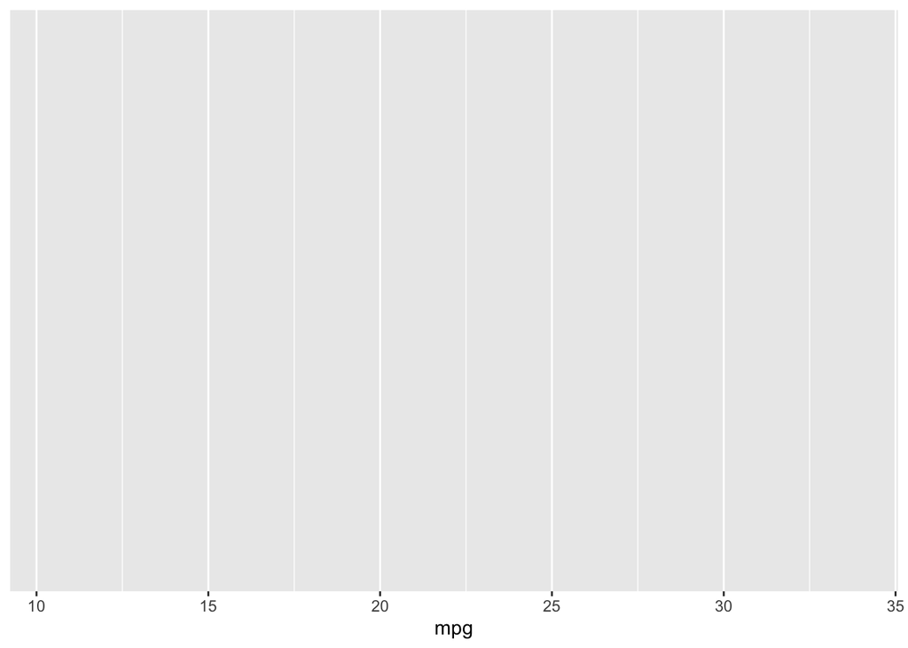

```r
p1 <- ggplot(mtcars, aes(x = mpg))

p1
```

The blank plot is expected. We have provided data and an x-axis mapping, but no geometric object yet.

Add a histogram.

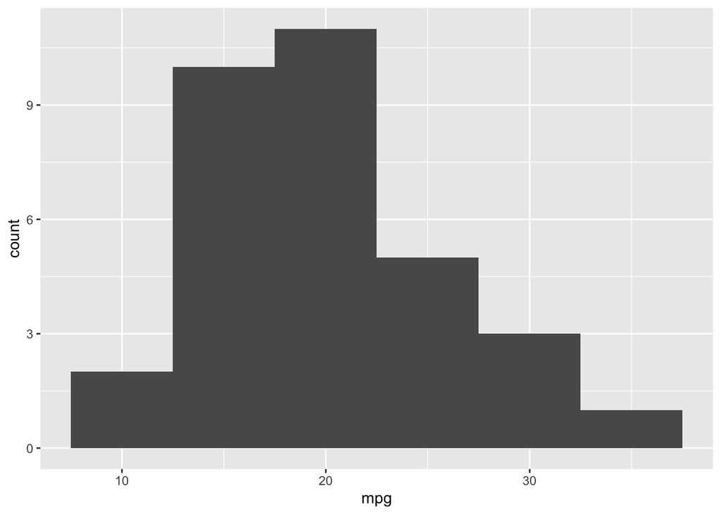

```r
p2 <- p1 +
  geom_histogram(binwidth = 5)

p2
```

Add labels.

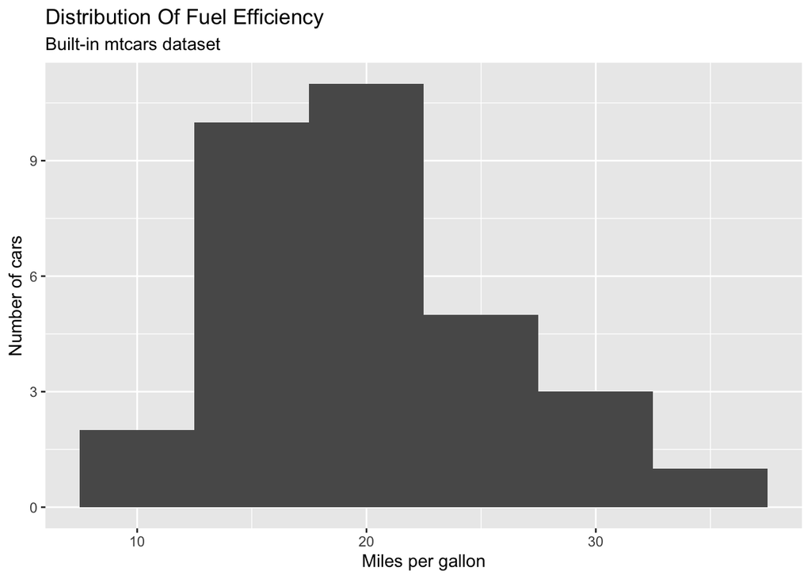

```r
p3 <- p2 +
  labs(
    title = "Distribution Of Fuel Efficiency",
    subtitle = "Built-in mtcars dataset",
    x = "Miles per gallon",
    y = "Number of cars"
  )

p3
```

Add a theme.

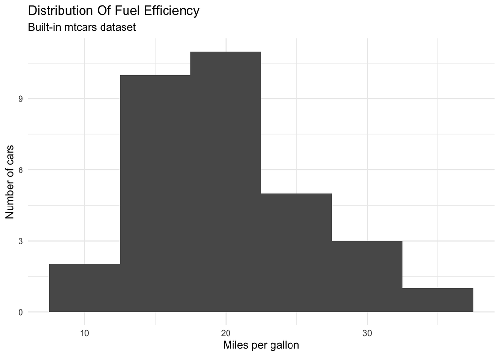

```r
p4 <- p3 +
  theme_minimal()

p4
```

# Check 5: Render Works

After rendering or previewing, confirm that:

- an HTML file was created or previewed
- the table appears
- the plot appears
- there are no error messages